# Project 1- Preprocessing

#Libraries

```r
library(dplyr)
library(missMDA)
library(FactoMineR)
library(car)
library(mice)
library (chemometrics)
library(MASS)
library(AER)
library(effects)
library(lmtest)
library(DescTools)
library(ResourceSelection)
library(statmod)
library(cvAUC)
library(caret)
library(ModelMetrics)
library(pROC)
```

#Load dataset and create dataframe

```r
df <- read.csv("../data/bank-full.csv",
               sep = ";")

summary(df)
```

```
      age            job              marital           education           default             balance         housing              loan             contact
 Min.   :18.00   Length:45211       Length:45211       Length:45211       Length:45211       Min.   : -8019   Length:45211       Length:45211       Length:45211
 1st Qu.:33.00   Class :character   Class :character   Class :character   Class :character   1st Qu.:    72   Class :character   Class :character   Class :character
 Median :39.00   Mode  :character   Mode  :character   Mode  :character   Mode  :character   Median :   448   Mode  :character   Mode  :character   Mode  :character
 Mean   :40.94                                                                               Mean   :  1362
 3rd Qu.:48.00                                                                               3rd Qu.:  1428
 Max.   :95.00                                                                               Max.   :102127
      day           month              duration         campaign          pdays          previous          poutcome              y
 Min.   : 1.00   Length:45211       Min.   :   0.0   Min.   : 1.000   Min.   : -1.0   Min.   :  0.0000   Length:45211       Length:45211
 1st Qu.: 8.00   Class :character   1st Qu.: 103.0   1st Qu.: 1.000   1st Qu.: -1.0   1st Qu.:  0.0000   Class :character   Class :character
 Median :16.00   Mode  :character   Median : 180.0   Median : 2.000   Median : -1.0   Median :  0.0000   Mode  :character   Mode  :character
 Mean   :15.81                      Mean   : 258.2   Mean   : 2.764   Mean   : 40.2   Mean   :  0.5803
 3rd Qu.:21.00                      3rd Qu.: 319.0   3rd Qu.: 3.000   3rd Qu.: -1.0   3rd Qu.:  0.0000
 Max.   :31.00                      Max.   :4918.0   Max.   :63.000   Max.   :871.0   Max.   :275.0000
```

```r
df_no_dupl <- distinct(df) #there are no duplicates in our dataset
rm(df_no_dupl)
```

#Exploratory analisis Assign correct datatype to each variable No missing values, so no imputation method is required

```r
sapply(df, class)
```

```
        age         job     marital   education     default     balance     housing        loan     contact         day       month    duration    campaign       pdays
  "integer" "character" "character" "character" "character"   "integer" "character" "character" "character"   "integer" "character"   "integer"   "integer"   "integer"
   previous    poutcome           y
  "integer" "character" "character"
```

```r
# Convert characaters to categorical variables
df[sapply(df, is.character)] <- lapply(df[sapply(df, is.character)], as.factor)
summary (df)
```

```
      age                 job           marital          education     default        balance       housing      loan            contact           day
 Min.   :18.00   blue-collar:9732   divorced: 5207   primary  : 6851   no :44396   Min.   : -8019   no :20081   no :37967   cellular :29285   Min.   : 1.00
 1st Qu.:33.00   management :9458   married :27214   secondary:23202   yes:  815   1st Qu.:    72   yes:25130   yes: 7244   telephone: 2906   1st Qu.: 8.00
 Median :39.00   technician :7597   single  :12790   tertiary :13301               Median :   448                           unknown  :13020   Median :16.00
 Mean   :40.94   admin.     :5171                    unknown  : 1857               Mean   :  1362                                             Mean   :15.81
 3rd Qu.:48.00   services   :4154                                                  3rd Qu.:  1428                                             3rd Qu.:21.00
 Max.   :95.00   retired    :2264                                                  Max.   :102127                                             Max.   :31.00
                 (Other)    :6835
     month          duration         campaign          pdays          previous           poutcome       y
 may    :13766   Min.   :   0.0   Min.   : 1.000   Min.   : -1.0   Min.   :  0.0000   failure: 4901   no :39922
 jul    : 6895   1st Qu.: 103.0   1st Qu.: 1.000   1st Qu.: -1.0   1st Qu.:  0.0000   other  : 1840   yes: 5289
 aug    : 6247   Median : 180.0   Median : 2.000   Median : -1.0   Median :  0.0000   success: 1511
 jun    : 5341   Mean   : 258.2   Mean   : 2.764   Mean   : 40.2   Mean   :  0.5803   unknown:36959
 nov    : 3970   3rd Qu.: 319.0   3rd Qu.: 3.000   3rd Qu.: -1.0   3rd Qu.:  0.0000
 apr    : 2932   Max.   :4918.0   Max.   :63.000   Max.   :871.0   Max.   :275.0000
 (Other): 6060
```

#Variables. From the dataset source: 1 - age (numeric) 487 outliers, all on the upper side. 3 of them severe. Not normally distributed

```r
summary(df[,1])
```

```
   Min. 1st Qu.  Median    Mean 3rd Qu.    Max.
  18.00   33.00   39.00   40.94   48.00   95.00
```

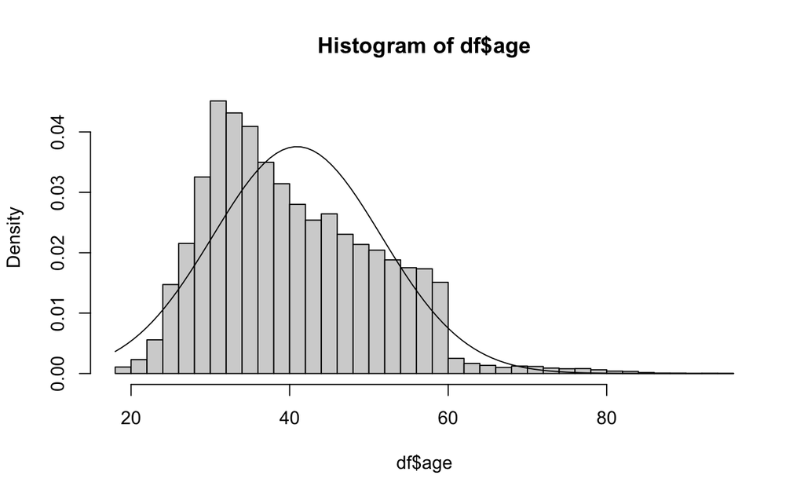

```r
hist(df$age, breaks = 40, freq = F);curve(dnorm(x, mean(df$age), sd(df$age)), add = T)
```

```
 [1] 33700 41664 31234 44263 44421 41935 42728 31070 43195 41163
```

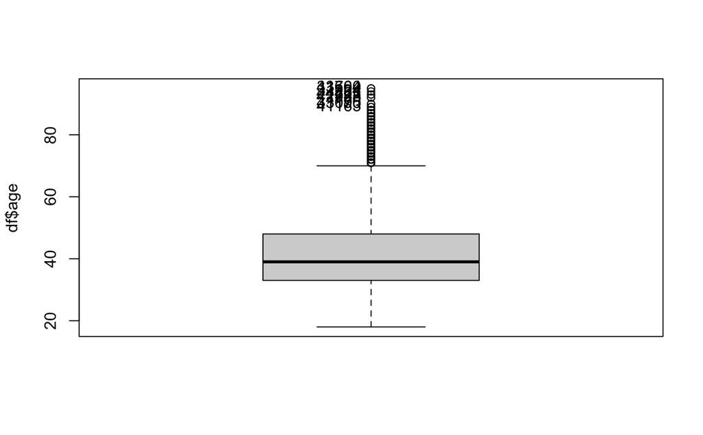

```r
Boxplot(df$age)
```

```
[1] 487
```

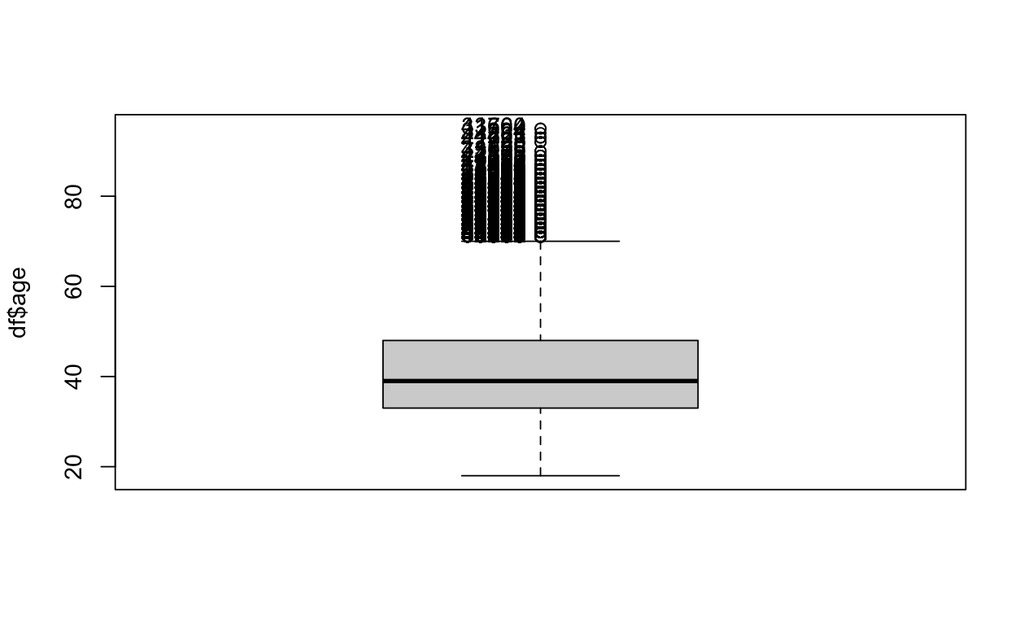

```r
length(Boxplot(df$age, id=list(n=Inf)))
```

```r
varsumm1<-summary (df[,1])
iqr1 <- varsumm1[5]-varsumm1[2]

umout1 <- varsumm1[5]+1.5*iqr1; umout1
```

```
3rd Qu.
   70.5
```

```r
usout1 <- varsumm1[5]+3*iqr1; usout1
```

```
3rd Qu.
     93
```

```r
lmout1 <- varsumm1[2]-1.5*iqr1; lmout1
```

```
1st Qu.
   10.5
```

```r
lsout1 <- varsumm1[2]-3*iqr1; lsout1
```

```
1st Qu.
    -12
```

```r
mout1<- which((df[,1]<lmout1)|(df[,1]>umout1));length(mout1) #487 mout
```

```
[1] 487
```

```r
sout1 <-which((df[,1]<lsout1)|(df[,1]>usout1));length(sout1) #3 sout
```

```
[1] 3
```

2 - job : type of job (categorical:“admin.”,“unknown”,“unemployed”,“management”,“housemaid”,“entrepreneur”,“student”,“blue-collar”,“self-employed”,“retired”,“technician”,“services”) 12 levels

```r
summary(df[,2])
```

```
       admin.   blue-collar  entrepreneur     housemaid    management       retired self-employed      services       student    technician    unemployed       unknown
         5171          9732          1487          1240          9458          2264          1579          4154           938          7597          1303           288
```

```r
str(df$job)
```

```
 Factor w/ 12 levels "admin.","blue-collar",..: 5 10 3 2 12 5 5 3 6 10 ...
```

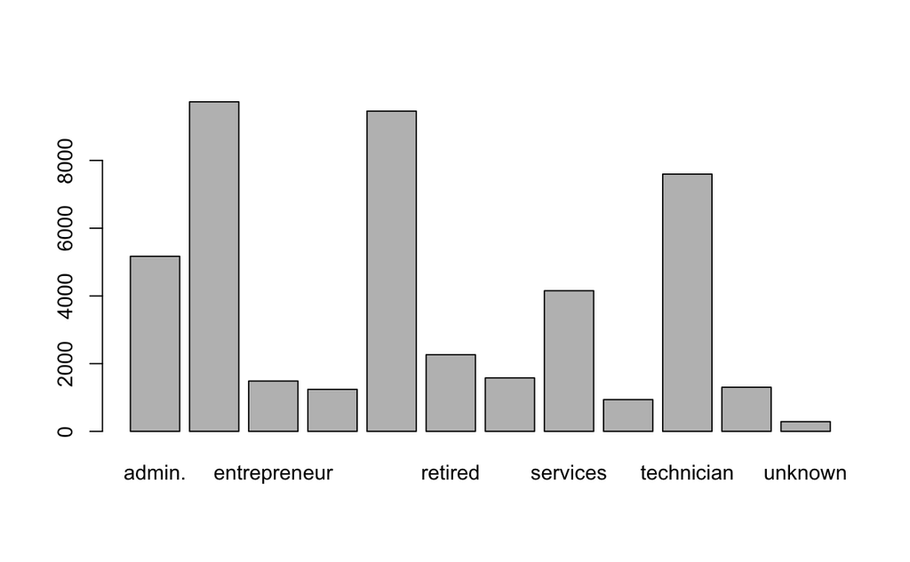

```r
plot(df$job)
```

3 - marital : marital status (categorical: “married”,“divorced”,“single”; note: “divorced” means divorced or widowed)

```r
summary(df[,3])
```

```
divorced  married   single
    5207    27214    12790
```

```r
str(df$marital)
```

```
 Factor w/ 3 levels "divorced","married",..: 2 3 2 2 3 2 3 1 2 3 ...
```

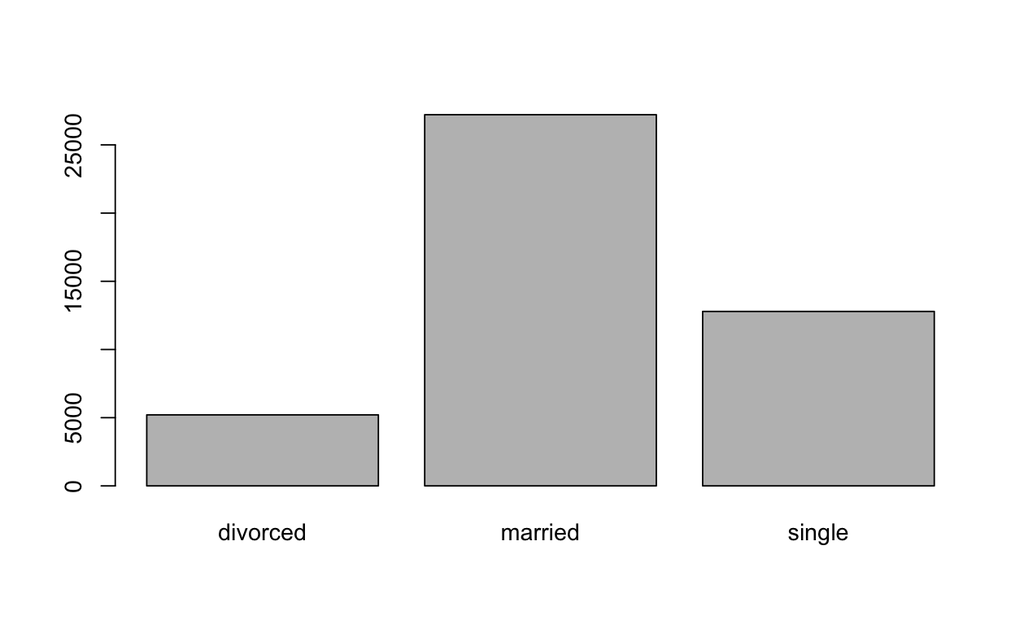

```r
plot(df$marital)
```

4 - education (categorical: “unknown”,“secondary”,“primary”,“tertiary”)

```r
summary(df[,4])
```

```
  primary secondary  tertiary   unknown
     6851     23202     13301      1857
```

```r
str(df$education)
```

```
 Factor w/ 4 levels "primary","secondary",..: 3 2 2 4 4 3 3 3 1 2 ...
```

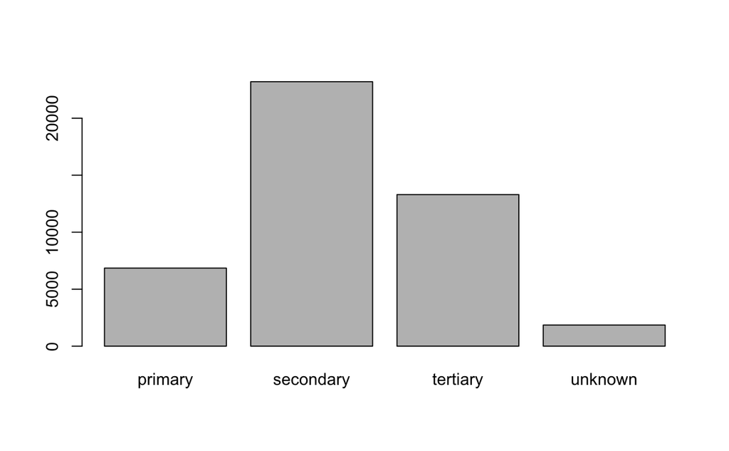

```r
plot(df$education)
```

5 - default: has credit in default? (binary: “yes”,“no”)

```r
summary(df[,5])
```

```
   no   yes
44396   815
```

```r
str(df$default)
```

```
 Factor w/ 2 levels "no","yes": 1 1 1 1 1 1 1 2 1 1 ...
```

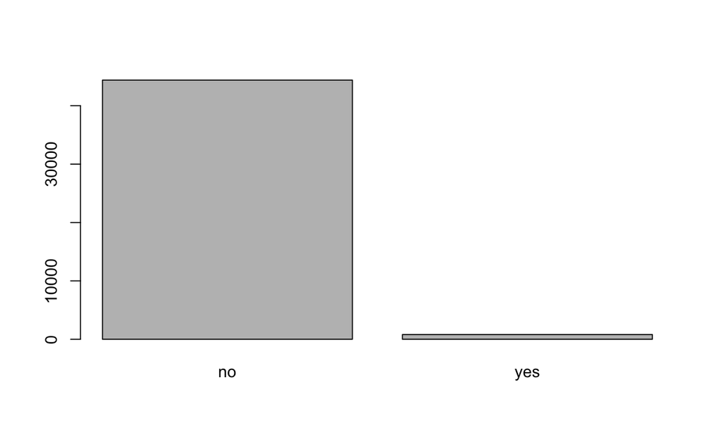

```r
plot(df$default)
```

```r
summary(df[,6])
```

```
   Min. 1st Qu.  Median    Mean 3rd Qu.    Max.
  -8019      72     448    1362    1428  102127
```

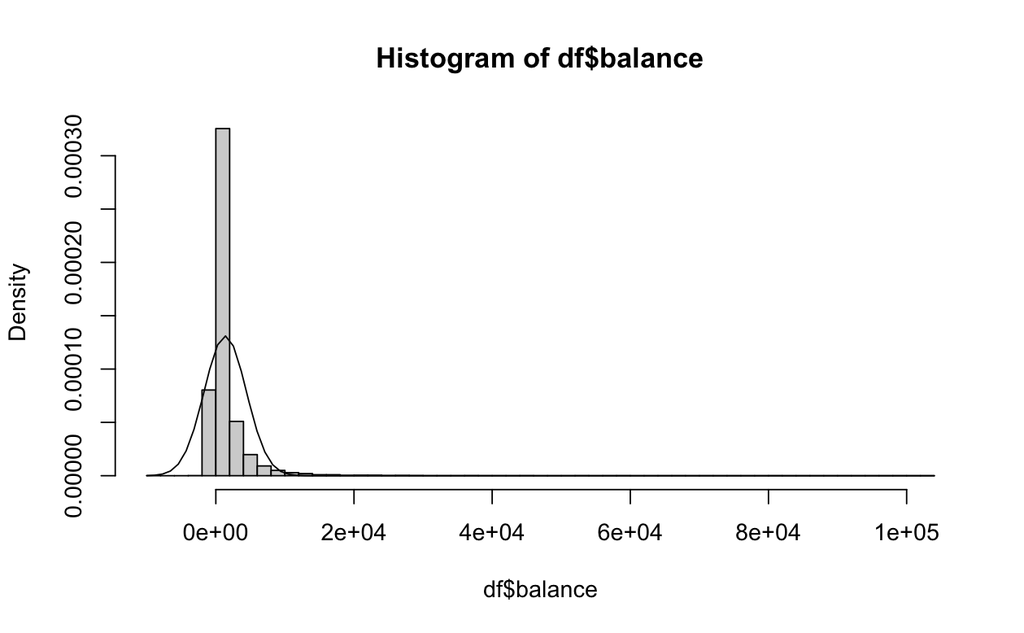

```r
hist(df$balance, breaks = 40, freq = F);curve(dnorm(x, mean(df$balance), sd(df$balance)), add = T)
```

```
 [1] 12910 15683 38737  7414  1897 32714 18574 31510 25120 14435 39990 26228 42559 43394 41694 19786 21193 19421 41375 12927
```

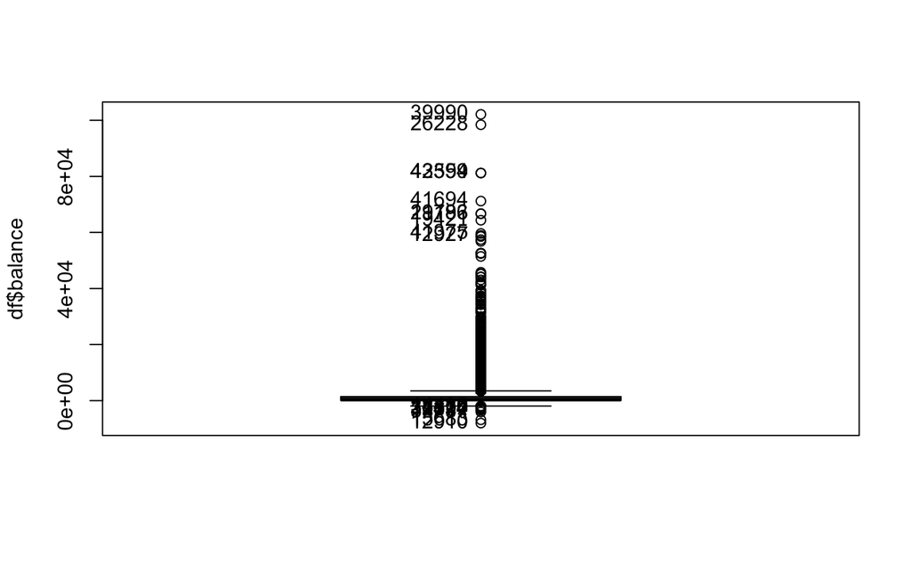

```r
Boxplot(df$balance)
```

```
[1] 4729
```

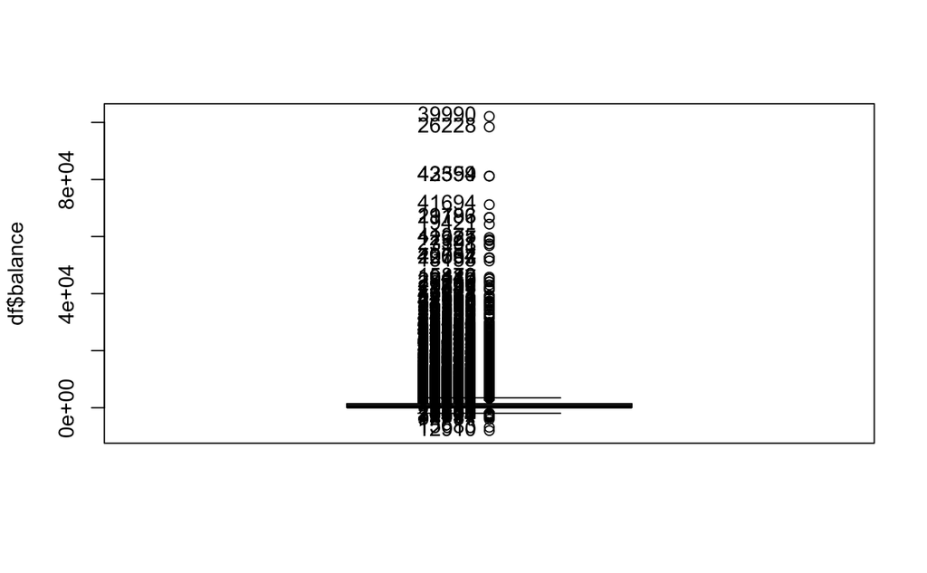

```r
length(Boxplot(df$balance, id=list(n=Inf)))
```

```r
varsumm6<-summary (df[,6])
iqr6 <- varsumm6[5]-varsumm6[2]

umout6 <- varsumm6[5]+1.5*iqr6; umout6
```

```
3rd Qu.
   3462
```

```r
usout6 <- varsumm6[5]+3*iqr6; usout6
```

```
3rd Qu.
   5496
```

```r
lmout6 <- varsumm6[2]-1.5*iqr6; lmout6
```

```
1st Qu.
  -1962
```

```r
lsout6 <- varsumm6[2]-3*iqr6; lsout6
```

```
1st Qu.
  -3996
```

```r
mout6<- which((df[,6]<lmout6)|(df[,6]>umout6));length(mout6) #4729 mout
```

```
[1] 4729
```

```r
sout6 <-which((df[,6]<lsout6)|(df[,6]>usout6));length(sout6) #2443 sout
```

```
[1] 2443
```

7 - housing: has housing loan? (binary: “yes”,“no”)

```r
summary(df[,7])
```

```
   no   yes
20081 25130
```

```r
str(df$housing)
```

```
 Factor w/ 2 levels "no","yes": 2 2 2 2 1 2 2 2 2 2 ...
```

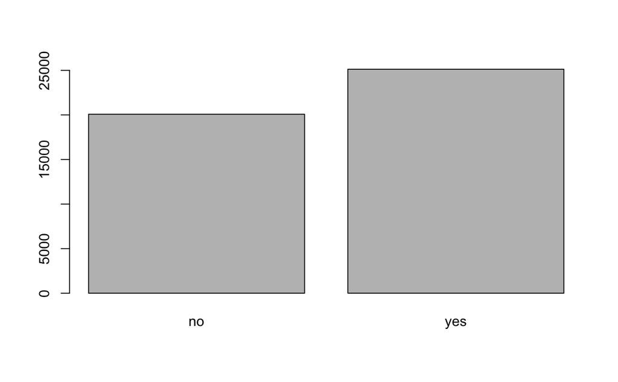

```r
plot(df$housing)
```

8 - loan: has personal loan? (binary: “yes”,“no”)

```r
summary(df[,8])
```

```
   no   yes
37967  7244
```

```r
str(df$loan)
```

```
 Factor w/ 2 levels "no","yes": 1 1 2 1 1 1 2 1 1 1 ...
```

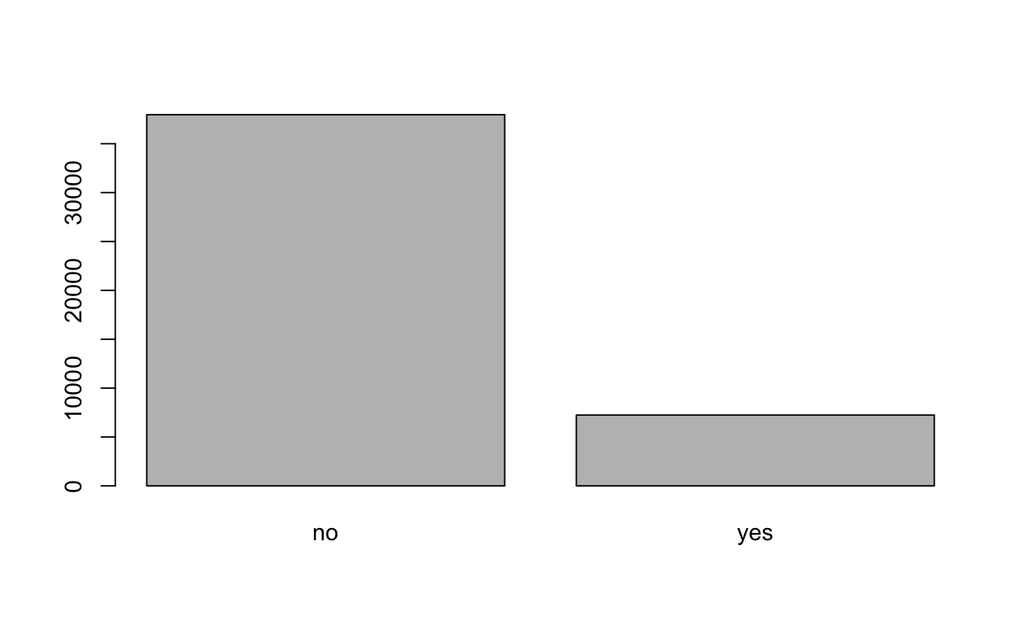

```r
plot(df$loan)
```

# related with the last contact of the current campaign:

9 - contact: contact communication type (categorical: “unknown”,“telephone”,“cellular”)

```r
summary(df[,9])
```

```
 cellular telephone   unknown
    29285      2906     13020
```

```r
str(df$contact)
```

```
 Factor w/ 3 levels "cellular","telephone",..: 3 3 3 3 3 3 3 3 3 3 ...
```

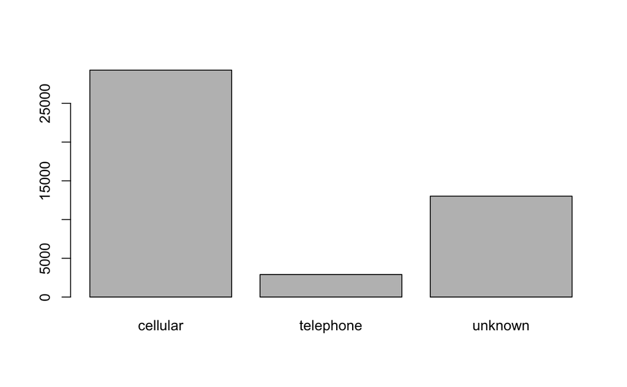

```r
plot(df$contact)
```

10 - day: last contact day of the month (numeric) doesn’t make sense to treat it as a numeric value

```r
df$day <- as.factor(df$day)
summary(df[,10])
```

```
   1    2    3    4    5    6    7    8    9   10   11   12   13   14   15   16   17   18   19   20   21   22   23   24   25   26   27   28   29   30   31
 322 1293 1079 1445 1910 1932 1817 1842 1561  524 1479 1603 1585 1848 1703 1415 1939 2308 1757 2752 2026  905  939  447  840 1035 1121 1830 1745 1566  643
```

```r
str(df$day)
```

```
 Factor w/ 31 levels "1","2","3","4",..: 5 5 5 5 5 5 5 5 5 5 ...
```

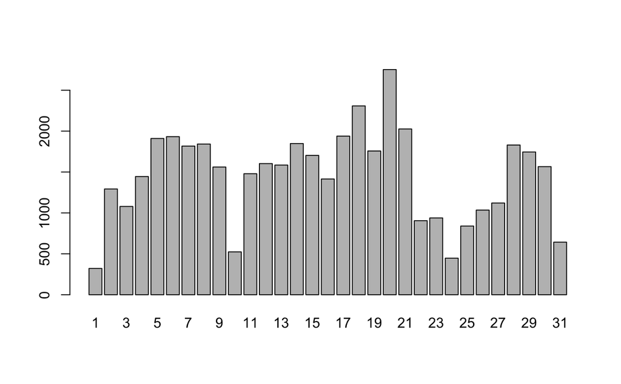

```r
plot(df$day)
```

11 - month: last contact month of year (categorical: “jan”, “feb”, “mar”, …, “nov”, “dec”) circular variable (after dec -> jan again)

```r
# Order
df$month <- factor(df$month,
                   levels = c("jan","feb","mar","apr","may","jun",
                              "jul","aug","sep","oct","nov","dec"),
                   ordered = TRUE)

#Cyclic codification
df$month_sin <- sin(2*pi*as.numeric(df$month)/12)
df$month_cos <- cos(2*pi*as.numeric(df$month)/12)

summary(df[,11])
```

```
  jan   feb   mar   apr   may   jun   jul   aug   sep   oct   nov   dec
 1403  2649   477  2932 13766  5341  6895  6247   579   738  3970   214
```

```r
str(df$month)
```

```
 Ord.factor w/ 12 levels "jan"<"feb"<"mar"<..: 5 5 5 5 5 5 5 5 5 5 ...
```

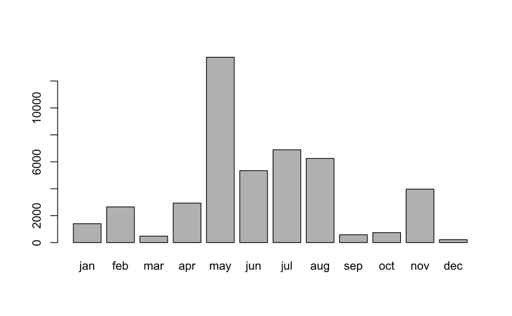

```r
plot(df$month)
```

12 - duration: last contact duration, in seconds (numeric) not normally dist

```r
summary(df[,12])
```

```
   Min. 1st Qu.  Median    Mean 3rd Qu.    Max.
    0.0   103.0   180.0   258.2   319.0  4918.0
```

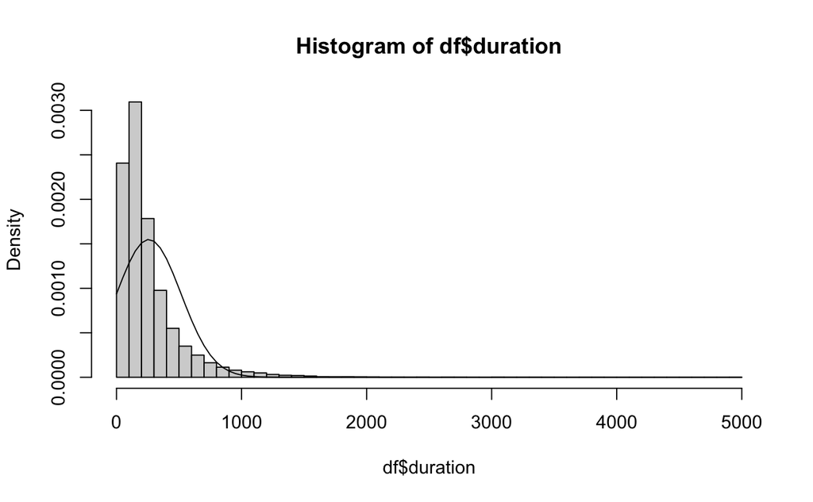

```r
hist(df$duration, breaks = 40, freq = F);curve(dnorm(x, mean(df$duration), sd(df$duration)), add = T)
```

```
 [1] 24149  9948 44603 19640  2387 21114 24096 24045 12348 30748
```

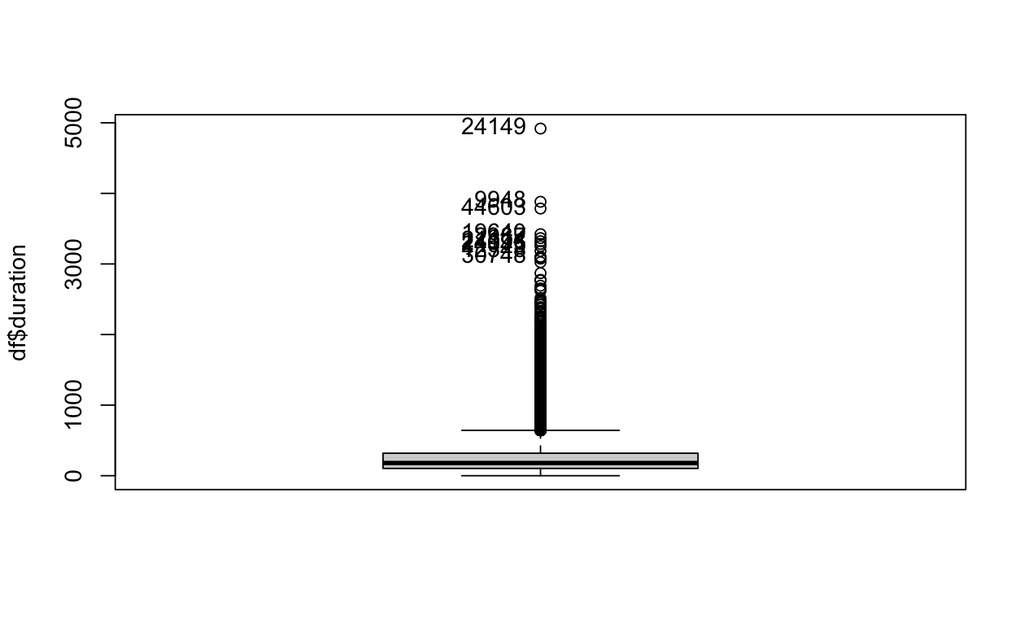

```r
Boxplot(df$duration)
```

```
[1] 3235
```

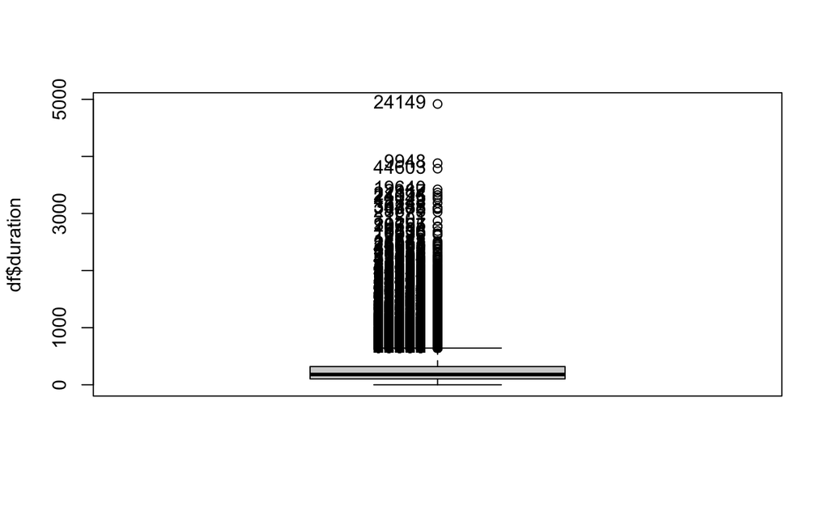

```r
length(Boxplot(df$duration, id=list(n=Inf)))
```

```r
varsumm12<-summary (df[,12])
iqr12 <- varsumm12[5]-varsumm12[2]

umout12 <- varsumm12[5]+1.5*iqr12; umout12
```

```
3rd Qu.
    643
```

```r
usout12<- varsumm12[5]+3*iqr12; usout12
```

```
3rd Qu.
    967
```

```r
lmout12<- varsumm12[2]-1.5*iqr12; lmout12
```

```
1st Qu.
   -221
```

```r
lsout12<- varsumm12[2]-3*iqr12; lsout12
```

```
1st Qu.
   -545
```

```r
mout12<- which((df[,12]<lmout12)|(df[,12]>umout12));length(mout12) #3235 mout
```

```
[1] 3235
```

```r
sout12<-which((df[,12]<lsout12)|(df[,12]>usout12));length(sout12) #1155 sout
```

```
[1] 1155
```

# other attributes:

13 - campaign: number of contacts performed during this campaign and for this client (numeric, includes last contact)

```r
summary(df[,13])
```

```
   Min. 1st Qu.  Median    Mean 3rd Qu.    Max.
  1.000   1.000   2.000   2.764   3.000  63.000
```

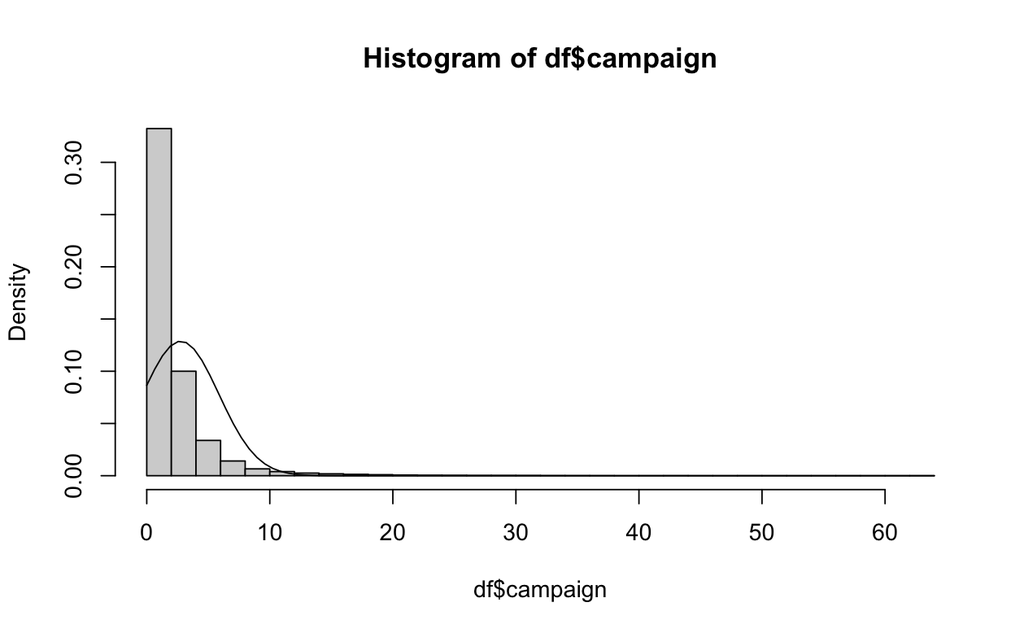

```r
hist(df$campaign, breaks = 40, freq = F);curve(dnorm(x, mean(df$campaign), sd(df$campaign)), add = T)
```

```
 [1]  4331 11915  5074  4300  5460 18714 10698 18745  4276 13676
```

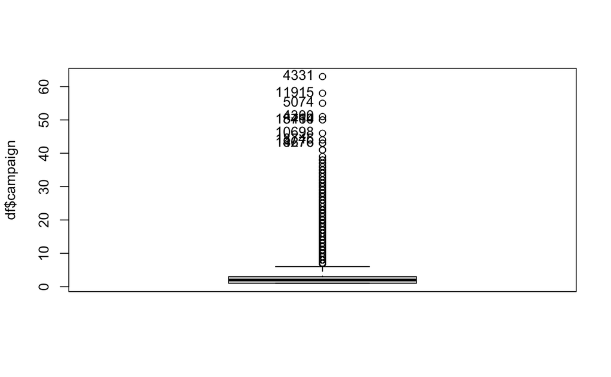

```r
Boxplot(df$campaign)
```

```
[1] 3064
```

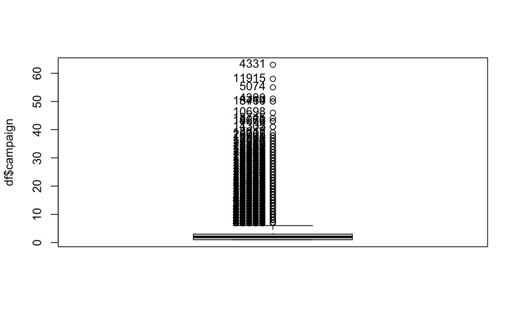

```r
length(Boxplot(df$campaign, id=list(n=Inf)))
```

```r
varsumm13<-summary (df[,13])
iqr13 <- varsumm13[5]-varsumm13[2]

umout13 <- varsumm13[5]+1.5*iqr13; umout13
```

```
3rd Qu.
      6
```

```r
usout13<- varsumm13[5]+3*iqr13; usout13
```

```
3rd Qu.
      9
```

```r
lmout13<- varsumm13[2]-1.5*iqr13; lmout13
```

```
1st Qu.
     -2
```

```r
lsout13<- varsumm13[2]-3*iqr13; lsout13
```

```
1st Qu.
     -5
```

```r
mout13<- which((df[,13]<lmout13)|(df[,13]>umout13));length(mout13) #3064 mout
```

```
[1] 3064
```

```r
sout13<-which((df[,13]<lsout13)|(df[,13]>usout13));length(sout13) #1462 sout
```

```
[1] 1462
```

14 - pdays: number of days that passed by after the client was last contacted from a previous campaign (numeric, -1 means client was not previously contacted) problematic variable. addressed in 2 different variables: - binary value if was contacted or not - replace -1 with nas: 82 % of NAs -> remove feature

```r
df$was_contacted <- ifelse(df$pdays == -1, 0, 1)
df$was_contacted <- as.factor(df$was_contacted)
summary(df$was_contacted)
```

```
    0     1
36954  8257
```

```r
str(df$was_contacted)
```

```
 Factor w/ 2 levels "0","1": 1 1 1 1 1 1 1 1 1 1 ...
```

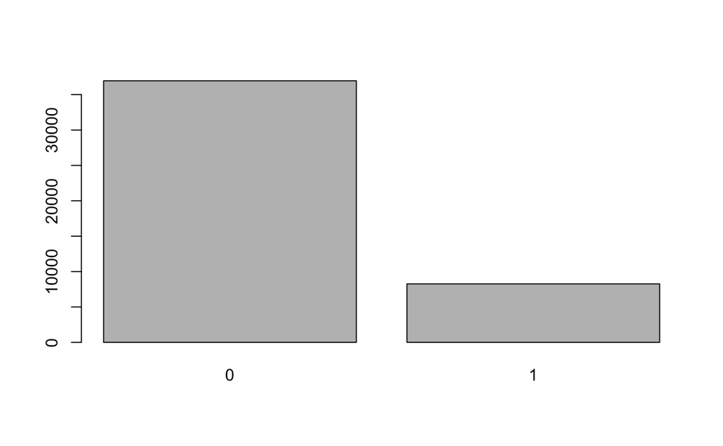

```r
plot(df$was_contacted)
```

```r
df$pdays <- ifelse(df$pdays == -1, NA, df$pdays)
summary (df$pdays)
```

```
   Min. 1st Qu.  Median    Mean 3rd Qu.    Max.    NA's
    1.0   133.0   194.0   224.6   327.0   871.0   36954
```

```r
df <- subset(df, select = -pdays)
summary(df)
```

```
      age                 job           marital          education     default        balance       housing      loan            contact           day
 Min.   :18.00   blue-collar:9732   divorced: 5207   primary  : 6851   no :44396   Min.   : -8019   no :20081   no :37967   cellular :29285   20     : 2752
 1st Qu.:33.00   management :9458   married :27214   secondary:23202   yes:  815   1st Qu.:    72   yes:25130   yes: 7244   telephone: 2906   18     : 2308
 Median :39.00   technician :7597   single  :12790   tertiary :13301               Median :   448                           unknown  :13020   21     : 2026
 Mean   :40.94   admin.     :5171                    unknown  : 1857               Mean   :  1362                                             17     : 1939
 3rd Qu.:48.00   services   :4154                                                  3rd Qu.:  1428                                             6      : 1932
 Max.   :95.00   retired    :2264                                                  Max.   :102127                                             5      : 1910
                 (Other)    :6835                                                                                                             (Other):32344
     month          duration         campaign         previous           poutcome       y           month_sin          month_cos       was_contacted
 may    :13766   Min.   :   0.0   Min.   : 1.000   Min.   :  0.0000   failure: 4901   no :39922   Min.   :-1.00000   Min.   :-1.0000   0:36954
 jul    : 6895   1st Qu.: 103.0   1st Qu.: 1.000   1st Qu.:  0.0000   other  : 1840   yes: 5289   1st Qu.:-0.50000   1st Qu.:-0.8660   1: 8257
 aug    : 6247   Median : 180.0   Median : 2.000   Median :  0.0000   success: 1511               Median : 0.00000   Median :-0.8660
 jun    : 5341   Mean   : 258.2   Mean   : 2.764   Mean   :  0.5803   unknown:36959               Mean   : 0.01845   Mean   :-0.4703
 nov    : 3970   3rd Qu.: 319.0   3rd Qu.: 3.000   3rd Qu.:  0.0000                               3rd Qu.: 0.50000   3rd Qu.:-0.5000
 apr    : 2932   Max.   :4918.0   Max.   :63.000   Max.   :275.0000                               Max.   : 1.00000   Max.   : 1.0000
 (Other): 6060
```

15 - previous: number of contacts performed before this campaign and for this client (numeric)

```r
summary(df[,14])
```

```
    Min.  1st Qu.   Median     Mean  3rd Qu.     Max.
  0.0000   0.0000   0.0000   0.5803   0.0000 275.0000
```

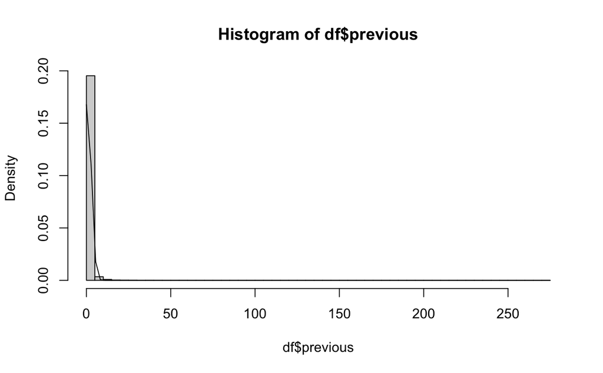

```r
hist(df$previous, breaks = 40, freq = F);curve(dnorm(x, mean(df$previous), sd(df$previous)), add = T)
```

```
 [1] 29183 38327 44090 28887 44823 42612 28499 37568 26669 42423
```

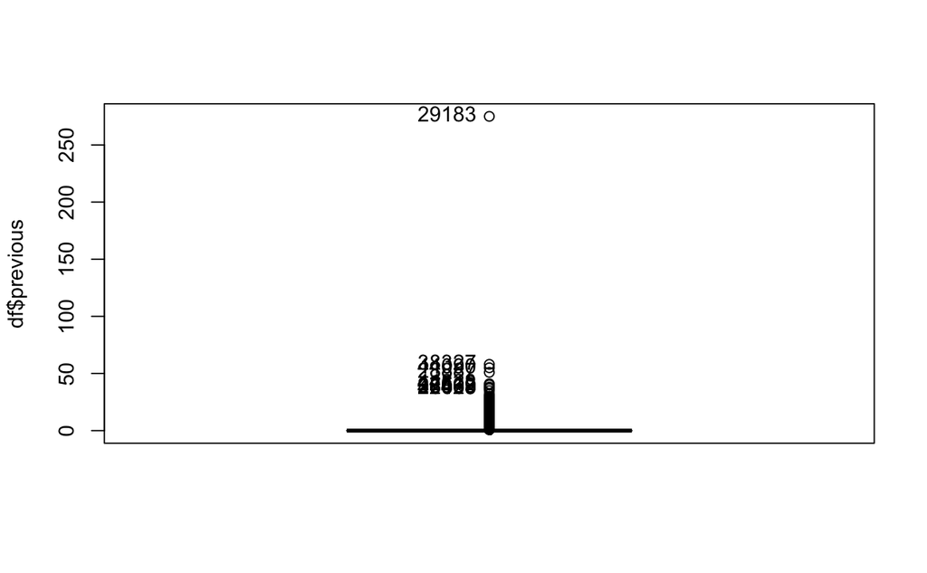

```r
Boxplot(df$previous)
```

```
[1] 8257
```

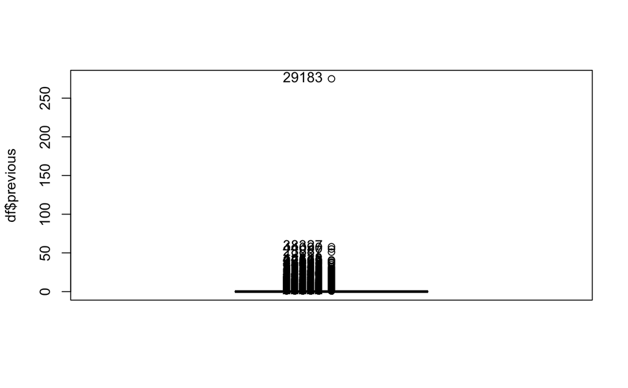

```r
length(Boxplot(df$previous, id=list(n=Inf)))
```

```r
varsumm14<-summary (df[,14])
iqr14 <- varsumm14[5]-varsumm14[2]

umout14 <- varsumm14[5]+1.5*iqr14; umout14
```

```
3rd Qu.
      0
```

```r
usout14<- varsumm14[5]+3*iqr14; usout14
```

```
3rd Qu.
      0
```

```r
lmout14<- varsumm14[2]-1.5*iqr14; lmout14
```

```
1st Qu.
      0
```

```r
lsout14<- varsumm14[2]-3*iqr14; lsout14
```

```
1st Qu.
      0
```

```r
mout14<- which((df[,14]<lmout14)|(df[,14]>umout14));length(mout14) #8257 mout
```

```
[1] 8257
```

```r
sout14<-which((df[,14]<lsout14)|(df[,14]>usout14));length(sout14) #8257 sout
```

```
[1] 8257
```

16 - poutcome: outcome of the previous marketing campaign (categorical: “unknown”,“other”,“failure”,“success”)

```r
summary(df[,15])
```

```
failure   other success unknown
   4901    1840    1511   36959
```

```r
str(df$poutcome)
```

```
 Factor w/ 4 levels "failure","other",..: 4 4 4 4 4 4 4 4 4 4 ...
```

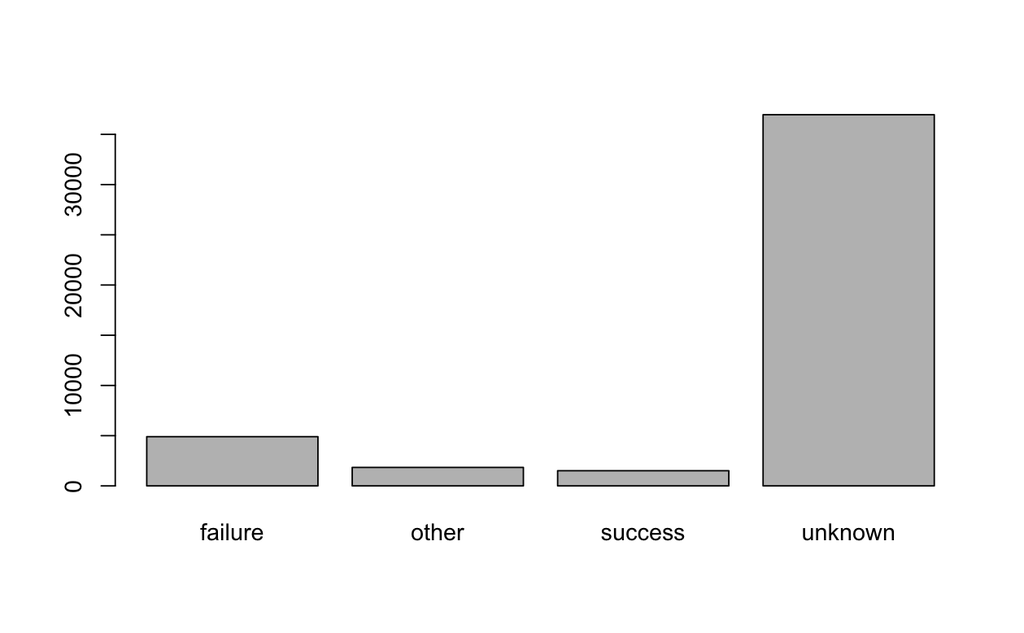

```r
plot(df$poutcome)
```

Output variable (desired target): 17 - y - has the client subscribed a term deposit? (binary: “yes”,“no”)

```r
summary(df[,16])
```

```
   no   yes
39922  5289
```

```r
str(df$y)
```

```
 Factor w/ 2 levels "no","yes": 1 1 1 1 1 1 1 1 1 1 ...
```

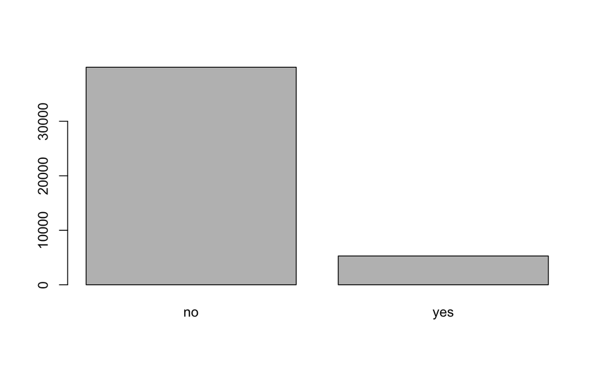

```r
plot(df$y)
```

Save clean dataset into an R object:

```r
df_clean <- df %>% dplyr::select(-month)
dir.create("artifacts", showWarnings = FALSE)
save(df_clean, file = "../artifacts/df_clean.RData")
```